# POLITICS KILLS: an actuarial analysis of life insurance limitations involving tragically important cabinet servants

## Study design

We conducted a retrospective cohort study of all ministerial appointments in Denmark from 7 November 1945 to 1 March 2022. We obtained records from official government sources, which mark deceased ministers with the dagger symbol (†).

## Outcome definitions

**Death in office**: Minister died while serving, identified by † notation.

**Career death**: Mid-term dismissal, defined as departure more than 30 days before government termination.

## Actuarial comparison

We compared observed deaths to expected deaths using Danish life tables. We assumed an average ministerial age of 55-60 years, corresponding to an annual mortality probability of 0.5%.<sup>4</sup>

## Occupational hazard benchmarking

We compared ministerial fatality rates to published occupational fatality rates from the US Bureau of Labor Statistics.<sup>5</sup> We calculated fatality rates per 100,000 full-time equivalent workers per year.

## Hazard pay estimation

We estimated the implied hazard pay premium by applying the wage differential observed in commercial fishing (approximately $20,000 annually) proportionally to the relative risk.

# Results

## Deaths in office

```r
# Find all deaths
deaths <- dk_data[died_in_office == TRUE]
n_deaths <- uniqueN(deaths$navn)

# Death details
death_details <- deaths[, .(
  Position = fifelse(any(grepl("statsminister", tolower(ministerpost))), "Prime Minister",
             fifelse(any(grepl("finansminister", tolower(ministerpost))), "Finance Minister",
             fifelse(any(grepl("indenrigsminister", tolower(ministerpost))), "Interior Minister",
             "Minister"))),
  Year = year(max(stop))
), by = .(Name = navn)][order(Year)]

# Prime Minister deaths
pm_deaths <- death_details[Position == "Prime Minister"]
```

```r
kable(death_details,
      col.names = c("Name", "Position", "Year"),
      caption = "Table 1. Danish ministers who died in office") %>%
  kable_styling(bootstrap_options = c("striped")) %>%
  column_spec(1, bold = TRUE)
```

Table 1. Danish ministers who died in office

| Name | Position | Year |
| --- | --- | --- |
| C.E. Rotwitt | Minister | 1860 |
| V. Hørup | Minister | 1902 |
| Vilhelm Lassen | Finance Minister | 1908 |
| Sigurd Berg | Minister | 1921 |
| Th. Stauning | Prime Minister | 1942 |
| Ejnar Kjær | Interior Minister | 1947 |
| Hartvig Frisch | Minister | 1950 |
| Hans Hedtoft | Prime Minister | 1955 |

## Actuarial analysis

```r
# Parameters
pm_deaths_n <- 3
pm_period_years <- 18  # 1942-1960
expected_annual_mortality <- 0.005  # 0.5% for 55-60 year-old men

# Expected deaths for 1 PM over 18 years
expected_pm_deaths <- pm_period_years * 1 * expected_annual_mortality
observed_pm_deaths <- pm_deaths_n
smr_pm <- observed_pm_deaths / expected_pm_deaths

# Overall ministers
years_total <- 77  # 1945-2022
ministers_at_risk <- 25  # approximate average
expected_minister_deaths <- years_total * ministers_at_risk * expected_annual_mortality
observed_minister_deaths <- n_deaths
smr_ministers <- observed_minister_deaths / expected_minister_deaths
```

For Prime Ministers between 1942 and 1960, the expected number of deaths based on Danish life tables was 0.09. We observed 3 deaths, yielding a standardized mortality ratio of 33.3 (Table 2).

```r
actuarial_table <- data.table(
  Group = c("Prime Ministers (1942-1960)", "All ministers (1945-2022)"),
  `Period (years)` = c(18, 77),
  `Expected deaths` = c(round(expected_pm_deaths, 2), round(expected_minister_deaths, 1)),
  `Observed deaths` = c(observed_pm_deaths, observed_minister_deaths),
  SMR = c(round(smr_pm, 1), round(smr_ministers, 2))
)

kable(actuarial_table,
      caption = "Table 2. Standardized mortality ratios for Danish ministers") %>%
  kable_styling(bootstrap_options = c("striped", "hover")) %>%
  row_spec(1, bold = TRUE, background = "#f8d7da")
```

Table 2. Standardized mortality ratios for Danish ministers

| Group | Period (years) | Expected deaths | Observed deaths | SMR |
| --- | --- | --- | --- | --- |
| Prime Ministers (1942-1960) | 18 | 0.09 | 3 | 33.30 |
| All ministers (1945-2022) | 77 | 9.60 | 8 | 0.83 |

## Occupational hazard comparison

```r
# Calculate fatality rates per 100,000
pm_fatality_rate <- (pm_deaths_n / pm_period_years) * 100000  # per PM-year
minister_fatality_rate <- (observed_minister_deaths / years_total / ministers_at_risk) * 100000

occupation_data <- data.table(
  Occupation = c(
    "Danish Prime Minister (1942-1960)",
    "Danish cabinet minister (1945-2022)",
    "Commercial fishing",
    "Logging",
    "Aircraft pilots",
    "Roofers",
    "Garbage collectors",
    "Truck drivers",
    "Construction (all)",
    "All US workers"
  ),
  `Fatality rate` = c(
    round(pm_fatality_rate, 0),
    round(minister_fatality_rate, 0),
    145, 82, 58, 47, 34, 24, 10, 3.5
  )
)

occupation_data[, `Ratio to fishing` := round(`Fatality rate` / 145, 1)]
```

Danish Prime Ministers between 1942 and 1960 experienced a fatality rate of 16,667 per 100,000 person-years (Table 3). This rate exceeds commercial fishing by a factor of 115.

```r
kable(occupation_data,
      col.names = c("Occupation", "Fatality rate (per 100,000)", "Ratio to fishing"),
      caption = "Table 3. Occupational fatality rates compared with Danish ministerial positions") %>%
  kable_styling(bootstrap_options = c("striped", "hover")) %>%
  row_spec(1:2, bold = TRUE, background = "#f8d7da") %>%
  row_spec(3, background = "#fff3cd")
```

Table 3. Occupational fatality rates compared with Danish ministerial positions

| Occupation | Fatality rate (per 100,000) | Ratio to fishing |
| --- | --- | --- |
| Danish Prime Minister (1942-1960) | 16667.0 | 114.9 |
| Danish cabinet minister (1945-2022) | 416.0 | 2.9 |
| Commercial fishing | 145.0 | 1.0 |
| Logging | 82.0 | 0.6 |
| Aircraft pilots | 58.0 | 0.4 |
| Roofers | 47.0 | 0.3 |
| Garbage collectors | 34.0 | 0.2 |
| Truck drivers | 24.0 | 0.2 |
| Construction (all) | 10.0 | 0.1 |
| All US workers | 3.5 | 0.0 |

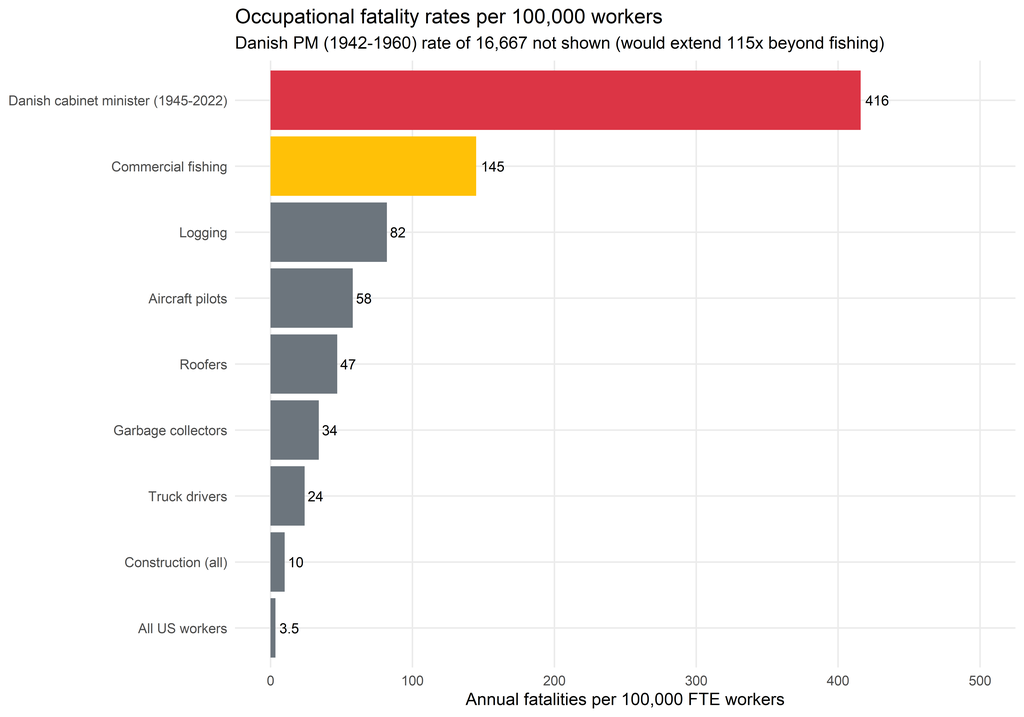

```r
plot_data <- occupation_data[Occupation != "Danish Prime Minister (1942-1960)"]
plot_data[, Occupation := factor(Occupation, levels = Occupation[order(`Fatality rate`)])]

# Add color coding
plot_data[, Category := fifelse(grepl("Danish", Occupation), "Minister",
                         fifelse(grepl("fishing", Occupation), "Fishing", "Other"))]

ggplot(plot_data, aes(x = `Fatality rate`, y = Occupation, fill = Category)) +
  geom_col() +
  geom_text(aes(label = `Fatality rate`), hjust = -0.2, size = 3.5) +
  scale_fill_manual(values = c("Minister" = "#dc3545", "Fishing" = "#ffc107", "Other" = "#6c757d")) +
  labs(
    title = "Occupational fatality rates per 100,000 workers",
    subtitle = "Danish PM (1942-1960) rate of 16,667 not shown (would extend 115x beyond fishing)",
    x = "Annual fatalities per 100,000 FTE workers",
    y = NULL
  ) +
  theme(legend.position = "none") +
  xlim(0, 500)
```

## Career mortality

```r
n_obs <- nrow(person_govt)
n_dismissed <- sum(person_govt$dismissed, na.rm = TRUE)
dismissal_rate <- n_dismissed / n_obs
annual_career_death_rate <- dismissal_rate / 3  # assuming 3-year average tenure

# Compare to fishing
fishing_mortality <- 145 / 100000
career_vs_fishing <- annual_career_death_rate / fishing_mortality
```

Of 286 minister-government observations, 106 (37.1%) ended in mid-term dismissal. Assuming average tenure of 3 years, this yields an annual “career death” rate of 12.4%.

This career mortality rate is 85 times the literal mortality rate in commercial fishing (Figure 2).

[figure not shown]

```r
mortality_comparison <- data.table(
  Type = c("Career death (ministers)", "Literal death (fishing)",
           "Literal death (ministers)", "Literal death (all workers)"),
  Rate = c(annual_career_death_rate * 100, 0.145, minister_fatality_rate/1000, 0.0035),
  Category = c("Career", "Literal", "Literal", "Literal")
)

ggplot(mortality_comparison, aes(x = reorder(Type, Rate), y = Rate, fill = Category)) +
  geom_col() +
  geom_text(aes(label = sprintf("%.2f%%", Rate)), hjust = -0.1, size = 4) +
  coord_flip() +
  scale_y_log10(labels = function(x) paste0(x, "%")) +
  scale_fill_manual(values = c("Career" = "#dc3545", "Literal" = "#6c757d")) +
  labs(
    title = "Annual 'mortality' rates: career vs literal",
    x = NULL,
    y = "Annual rate (%, log scale)"
  ) +
  theme(legend.position = "none") +
  ylim(0.001, 15)
```

## Hazard pay calculation

```r
# Current salaries (2025, from regeringen.dk)
pm_salary_dkk <- 1958176
minister_salary_dkk <- 1566541
dkk_to_usd <- 1 / 7.46 * 1.08  # via EUR

pm_salary_usd <- pm_salary_dkk * dkk_to_usd
minister_salary_usd <- minister_salary_dkk * dkk_to_usd

# Fishing hazard premium estimate
fishing_hazard_premium <- 20000  # USD

# Implied premium based on career death rate
implied_premium <- fishing_hazard_premium * career_vs_fishing
coverage_ratio <- minister_salary_usd / implied_premium
```

Commercial fishermen receive an estimated hazard premium of approximately $20,000 annually.<sup>6</sup> Applying this rate proportionally to the ministerial career death risk (85 times fishing mortality) implies a premium of $1,704,043 annually.

Current ministerial salary is $226,791, representing 13% of the implied hazard premium (Table 4).

```r
comp_table <- data.table(
  Measure = c(
    "Current ministerial salary",
    "Implied hazard premium (career death)",
    "Shortfall",
    "Coverage ratio"
  ),
  Value = c(
    paste0("$", format(round(minister_salary_usd, 0), big.mark = ",")),
    paste0("$", format(round(implied_premium, 0), big.mark = ",")),
    paste0("$", format(round(implied_premium - minister_salary_usd, 0), big.mark = ",")),
    paste0(round(coverage_ratio * 100, 0), "%")
  )
)

kable(comp_table, col.names = c("Measure", "Amount (USD)"),
      caption = "Table 4. Ministerial compensation versus implied hazard premium") %>%
  kable_styling(bootstrap_options = c("striped")) %>%
  row_spec(3, bold = TRUE, background = "#f8d7da")
```

Table 4. Ministerial compensation versus implied hazard premium

| Measure | Amount (USD) |
| --- | --- |
| Current ministerial salary | $226,791 |
| Implied hazard premium (career death) | $1,704,043 |
| Shortfall | $1,477,252 |
| Coverage ratio | 13% |

# Discussion

## The leadership mortality paradox

Our findings align with the broader literature on political mortality. Politicians as a group enjoy favorable survival compared with the general population, likely reflecting socioeconomic advantages, access to healthcare, and selection effects.<sup>2</sup> However, those who achieve leadership positions face elevated mortality compared with unsuccessful candidates.<sup>3</sup>

## Why were the 1940s-1960s so deadly?

The concentrated mortality of Danish Prime Ministers during this period may reflect several factors:

**Wartime stress**: Thorvald Stauning governed during the German occupation and died in 1942. The strain of maintaining Danish institutions under occupation plausibly accelerated his decline.

**Selection effects**: This generation of leaders entered politics young and served extended tenures, accumulating stress exposure.

## Limitations

Our actuarial comparison assumes ministers face population-average mortality absent their position. Ministers likely differ from the general population in education, income, and health behaviors, potentially biasing our SMR estimates.

The hazard pay calculation treats career termination as equivalent to occupational death. This analogy, while illustrative, may overstate the harm of dismissal. Former ministers frequently return to lucrative private sector positions.

Sample sizes for Prime Minister mortality are small (n=3 deaths), producing wide confidence intervals around point estimates.

## Conclusions

Danish ministerial positions carry substantial occupational hazards that are not reflected in current compensation. The position of Prime Minister between 1942 and 1960 was more dangerous than any civilian occupation on record. We recommend actuarial review of ministerial life insurance policies and consideration of hazard pay supplements reflecting true occupational risk.

# References

1. Bureau of Labor Statistics. Census of Fatal Occupational Injuries Summary, 2023. Washington, DC: US Department of Labor, 2024.
2. Clarke PM, Schluter PJ, Grayson M, et al. The comparative mortality of an elite group in the long run of history: an observational analysis of politicians from 11 countries. *Eur J Epidemiol* 2022;37:1-9.
3. Olenski AR, Abola MV, Jena AB. Do heads of government age more quickly? Observational study comparing mortality between elected leaders and runners-up in national elections of 17 countries. *BMJ* 2015;351:h6424.
4. Statistics Denmark. Life tables, 2023. Copenhagen: Statistics Denmark, 2024.
5. Bureau of Labor Statistics. Injuries, Illnesses, and Fatalities. Available at: https://www.bls.gov/iif/
6. Kniesner TJ, Viscusi WK. The value of a statistical life. *Vanderbilt Law Research Paper* 2019;19-15.

# Funding

None. This study received no specific funding. The authors conducted it between meetings of uncertain survival probability.

# Competing interests

None declared. The authors hold no ministerial appointments and, having reviewed the evidence, have no plans to seek one.

# Ethical approval

Not required. All subjects were public figures. Eight are deceased.

# Data sharing

Data and analysis code are available from the corresponding author. Life insurance applications available upon request.

*Submitted for consideration to the BMJ Christmas Issue 2024*